# Dinheiro em Circulação

```r
load(file="bcb.RData")
library(ggplot2)
library(scales)
library(knitr)
library(kableExtra)
```

Neste notebook vamos inspecionar os dados referentes à moeda em circulação no Brasil, dados compartilhados pelo Banco Central do Brasil, no link http://www.bcb.gov.br/adm/mecir/dadosabertos/MeioCirculante_DadosAbertos.csv e que obtive através do site **dados.gov.br**, recurso http://dados.gov.br/dataset/dinheiro-em-circulacao

# Quantidades e valores totais

```r
maxDate <- max(data$Data)

# data from most recent date
mrData <- data[data$Data == maxDate,]
mrData$Total <- mrData$Denom * mrData$Quant
```

As informações mais atuais de circulação de moeda no Brasil são de **15/07/2022**. Para esta data, temos **129** diferentes famílias de moedas em circulação.

As 10 famílias com maior quantidade em circulação são as seguintes:

```r
viewData <- mrData[order(-mrData$Quant),]

viewData <- data.frame(
  'Família'=
    substr(as.character(viewData$Familia), 1, 30),
  'Denominação'=
    paste("R$",
          format(viewData$Denom, format="f", big.mark=".", decimal.mark=",", digits=2)),
  'Quantidade'=
    paste(format(round(viewData$Quant / 1E+9, 2), format="f", big.mark=".", decimal.mark=","), "bi"),
  'Total'=
    paste("R$",
          format(round(viewData$Total / 1E+6, 2), format="f", big.mark=".", decimal.mark=","), "mi")
  )

head(viewData, 10) %>%
  kable(align = 'lrrr') %>%
  kable_styling(bootstrap_options = "striped", full_width = F)
```

| Família | Denominação | Quantidade | Total |
| --- | --- | --- | --- |
| Moedas - 2a. Família | R$ 0,10 | 6,25 bi | R$ 625,34 mi |
| Moedas - 2a. Família | R$ 0,05 | 6,01 bi | R$ 300,62 mi |
| Moedas - 2a. Família | R$ 1,00 | 3,53 bi | R$ 3.534,34 mi |
| Moedas - 2a. Família | R$ 0,25 | 2,94 bi | R$ 735,14 mi |
| Moedas - 2a. Família | R$ 0,50 | 2,88 bi | R$ 1.442,39 mi |
| Moedas - 1a. Família (inox) | R$ 0,01 | 1,99 bi | R$ 19,91 mi |
| Cédulas - 2a. família | R$ 50,00 | 1,86 bi | R$ 93.184,18 mi |
| Cédulas - 2a. família | R$ 100,00 | 1,75 bi | R$ 174.803,43 mi |
| Moedas - 1a. Família (inox) | R$ 0,10 | 1,40 bi | R$ 140,06 mi |
| Cédulas - 2a. família | R$ 2,00 | 1,38 bi | R$ 2.753,68 mi |

Já as 5 famílias mais raras em circulação no Brasil são as seguintes:

```r
viewData <- mrData[order(mrData$Quant),]

viewData <- data.frame(
  'Família'=
    substr(as.character(viewData$Familia), 1, 30),
  'Denominação'=
    paste("R$", format(viewData$Denom, format="f", big.mark=".", decimal.mark=",", digits=2)),
  'Quantidade'=
    format(viewData$Quant, format="f", big.mark=".", decimal.mark=","),
  'Total'=
    paste("R$", format(viewData$Total, format="f", big.mark=".", decimal.mark=","))
  )

head(viewData, 5) %>%
  kable(align = 'lrrr') %>%
  kable_styling(bootstrap_options = "striped", full_width = F)
```

| Família | Denominação | Quantidade | Total |
| --- | --- | --- | --- |
| Moedas comemorativas Portinari | R$ 2,00 | 2.000 | R$ 4.000 |
| Moedas comemorativas duzentos | R$ 5,00 | 2.000 | R$ 10.000 |
| Moedas comemorativas Ouro Pret | R$ 5,00 | 2.000 | R$ 10.000 |
| Moedas comemorativas Tetra cam | R$ 20,00 | 2.000 | R$ 40.000 |
| Moedas comemorativas Juscelino | R$ 20,00 | 2.499 | R$ 49.980 |

Eu nunca vi nenhuma destas! Se você encontrar alguma, guarde para a sua coleção!

E por fim, temos que o total de moeda em circulação no Brasil é de **R$ 328.1 bilhões**.

# Substituição de cédulas e moedas

Vamos analisar a substituição de cédulas em circulação no Brasil? Ao longo dos anos a primeira família de cédulas foi sendo substuída gradualmente pelas cédulas da segunda família. Ainda existiu uma terceira família, as notas de R$ 10 feitas de polímero. Eu me recordo vagamente delas, mas estatisticamente são insignificantes e por isso tirei do gráfico. Foi uma experiência apenas com a nota de R$ 10, e hoje não se vê mais ela por aí…

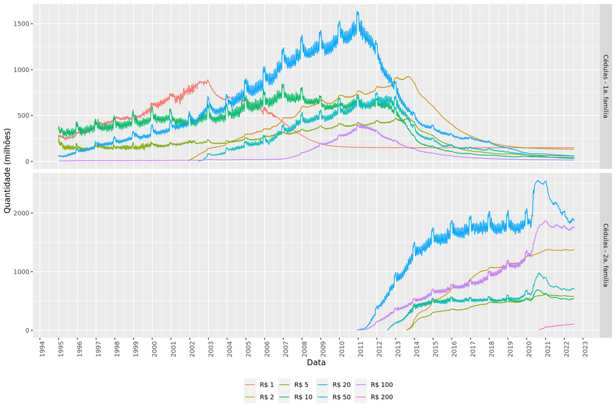

```r
notes <- data[grepl("Cédulas - [1-9]a. família", data$Familia),]

notes$Denom <-
  factor(notes$Denom,
         levels=c(1, 2, 5, 10, 20, 50, 100, 200),
         labels=c("R$ 1", "R$ 2", "R$ 5", "R$ 10", "R$ 20", "R$ 50", "R$ 100", "R$ 200"))

ggplot(data=notes) +
  geom_line(aes(x=Data, y=Quant / 1E+6, color=Denom)) +
  facet_grid(Familia~., scales="free_y") +
  xlab("Data") + ylab("Quantidade (milhões)") +
  scale_x_date(labels = date_format("%Y"), breaks = date_breaks("year")) +
  theme(axis.text.x = element_text(angle = 90, hjust = 1),
        legend.title=element_blank(),
        legend.position = "bottom")
```

No que se refere às moedas, interessante que não há registro de retirada da primeira família de moedas do mercado desde 2008. Mas não faz sentido haver 2 bilhões de moedades de 1 centavo, por exemplo, em circulação. Eu ao menos nunca mais vi esta moedinha. Quando se fala em moedas, há dezenas de versões comemorativas, que podem interessar aos colecionadores, mas aqui nas nossas estatísticas foram desconsideradas.

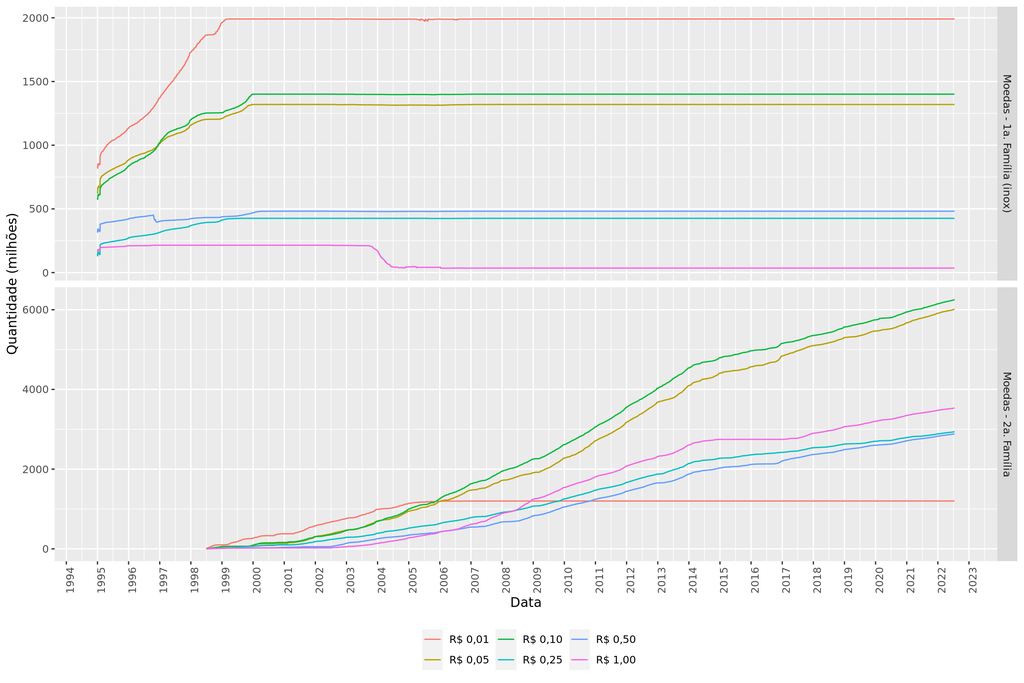

```r
coins <- data[data$Familia %in% c("Moedas - 1a. Família (inox)",
                                  "Moedas - 2a. Família"),]

coins$Denom <-
  factor(coins$Denom,
         levels=c(0.01, 0.05, 0.10, 0.25, 0.5, 1),
         labels=c("R$ 0,01", "R$ 0,05", "R$ 0,10", "R$ 0,25", "R$ 0,50", "R$ 1,00"))

ggplot(data=coins) +
  geom_line(aes(x=Data, y=Quant / 1E+6, color=Denom)) +
  facet_grid(Familia~., scales = "free_y") +
  xlab("Data") + ylab("Quantidade (milhões)") +
  scale_x_date(labels = date_format("%Y"), breaks = date_breaks("year")) +
  theme(axis.text.x = element_text(angle = 90, hjust = 1),
        legend.title=element_blank(),
        legend.position = "bottom")
```